# AllLife Bank - Personal Loan Campaign

# Improving Model Performance

### Optimal threshold using AUC-ROC curve

- I'm going to try and increase Recall, by changing the threshold using AUC-ROC Curve.

```python
# For optimal threshold we want an AUC-ROC curve with high tpr and low fpr
fpr, tpr, thresh = roc_curve(y_train, lg.predict_proba(X_train)[:, 1])

optimal_idx = np.argmax(tpr - fpr)
optimal_thresh_auc_roc = thresholds[optimal_idx]
print(optimal_thresh_auc_roc)
```

```
0.07916084583939298
```

# Checking model performance on training set

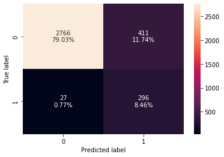

```python
# create confusion matrix
confusion_matrix_sklearn_threshold(
    lg, X_train, y_train, threshold = optimal_thresh_auc_roc
)
```

```python
# check new model performance
log_reg_model_train_perf_threshold_auc_roc = model_perf_class_sklearn_threshold(
    lg, X_train, y_train, threshold = optimal_thresh_auc_roc
)

print('Training Performance:')
log_reg_model_train_perf_threshold_auc_roc
```

```
Training Performance:
```

|  | Accuracy | Recall | Precision | F1 |
| --- | --- | --- | --- | --- |
| 0 | 0.874857 | 0.916409 | 0.41867 | 0.574757 |

- Recall has improved significantly on the training set. It increased from 0.62 to 0.92
- Our other metrics have decreased some though, most notably precision is now about half what is was before, this is a drop from 0.84 to 0.41, while accuracy dropped from 0.95 to 0.87 and f1 dropped from 0.71 to 0.57
- A better threshold is needed in order to find a good balance amongst the different metrics.

## Let's use Precision-Recall curve and see if we can find a better threshold

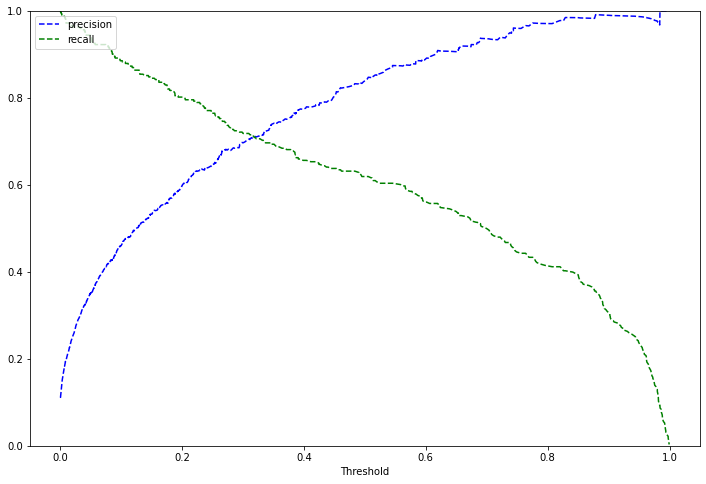

```python
y_scores = lg.predict_proba(X_train)[:, 1]
prec, rec, tre = precision_recall_curve(y_train, y_scores)

def plot_prec_recall_vs_tresh(precisions, recalls, thresholds):
    plt.plot(thresholds, precisions[:-1], 'b--', label='precision')
    plt.plot(thresholds, recalls[:-1], '--g', label='recall')
    plt.xlabel('Threshold')
    plt.legend(loc='upper left')
    plt.ylim([0, 1])

plt.figure(figsize=(12, 8))
plot_prec_recall_vs_tresh(prec, rec, tre)
plt.show()
```

- At threshold around 0.32 - 0.34 we will get equal precision and recall but I want a higher recall while keeping a good precision, so I think I'll go with 0.30

```python
# set threshold
optimal_threshold_curve = 0.30
```

## Checking model performance on training set

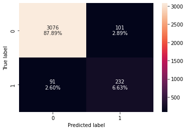

```python
# creating confusion matrix
confusion_matrix_sklearn_threshold(
    lg, X_train, y_train, threshold=optimal_threshold_curve
)
```

```python
log_reg_model_train_perf_threshold_curve = model_perf_class_sklearn_threshold(
    lg, X_train, y_train, threshold=optimal_threshold_curve
)
print("Training performance:")
log_reg_model_train_perf_threshold_curve
```

```
Training performance:
```

|  | Accuracy | Recall | Precision | F1 |
| --- | --- | --- | --- | --- |
| 0 | 0.945143 | 0.718266 | 0.696697 | 0.707317 |

# Model Performance Summary

```python
# performance comparison

models_train_comp_df = pd.concat(
    [
        log_reg_model_train_perf.T,
        log_reg_model_train_perf_threshold_auc_roc.T,
        log_reg_model_train_perf_threshold_curve.T,
    ],
    axis=1,
)
models_train_comp_df.columns = [
    "Logistic Regression sklearn",
    "Logistic Regression-0.079 Threshold",
    "Logistic Regression-0.30 Threshold",
]

print("Training performance comparison:")
models_train_comp_df
```

```
Training performance comparison:
```

|  | Logistic Regression sklearn | Logistic Regression-0.079 Threshold | Logistic Regression-0.30 Threshold |
| --- | --- | --- | --- |
| Accuracy | 0.954000 | 0.874857 | 0.945143 |
| Recall | 0.619195 | 0.916409 | 0.718266 |
| Precision | 0.840336 | 0.418670 | 0.696697 |
| F1 | 0.713012 | 0.574757 | 0.707317 |

# Let's check the performance on the test set

- initially we will check using the default threshold of 0.50

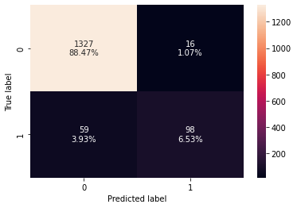

```python
# create confusion matrix
confusion_matrix_sklearn_threshold(lg, X_test, y_test)
```

```python
log_reg_model_test_perf = model_perf_class_sklearn_threshold(
    lg, X_test, y_test
)

print("Test set performance:")
log_reg_model_test_perf
```

```
Test set performance:
```

|  | Accuracy | Recall | Precision | F1 |
| --- | --- | --- | --- | --- |
| 0 | 0.95 | 0.624204 | 0.859649 | 0.723247 |

### ROC-AUC on test set

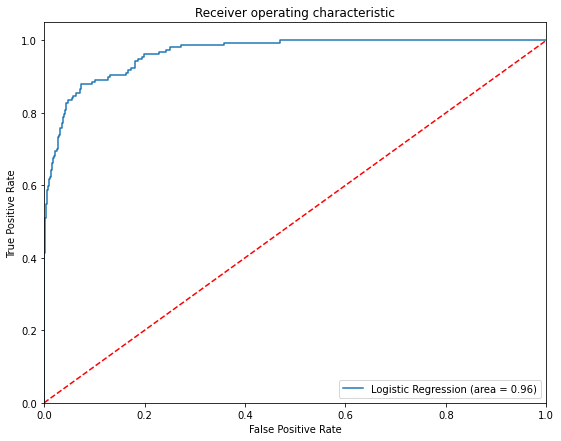

```python
logit_roc_auc_test = roc_auc_score(y_test, lg.predict_proba(X_test)[:, 1])
fpr, tpr, thresholds = roc_curve(y_test, lg.predict_proba(X_test)[:, 1])
plt.figure(figsize=(9, 7))
plt.plot(fpr, tpr, label="Logistic Regression (area = %0.2f)" % logit_roc_auc_test)
plt.plot([0, 1], [0, 1], "r--")
plt.xlim([0.0, 1.0])
plt.ylim([0.0, 1.05])
plt.xlabel("False Positive Rate")
plt.ylabel("True Positive Rate")
plt.title("Receiver operating characteristic")
plt.legend(loc="lower right")
plt.show()
```

### Using the model with threshold of 0.079

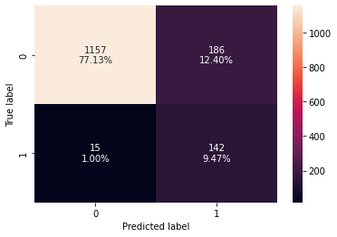

```python
# create confusion matrix
confusion_matrix_sklearn_threshold(
    lg, X_test, y_test, threshold=optimal_thresh_auc_roc
)
```

```python
# performance for new model
log_reg_model_test_perf_threshold_auc_roc = model_perf_class_sklearn_threshold(
    lg, X_test, y_test, threshold=optimal_thresh_auc_roc
)
print("Test set performance:")
log_reg_model_test_perf_threshold_auc_roc
```

```
Test set performance:
```

|  | Accuracy | Recall | Precision | F1 |
| --- | --- | --- | --- | --- |
| 0 | 0.866 | 0.904459 | 0.432927 | 0.585567 |

### Using the model with threshold 0.30

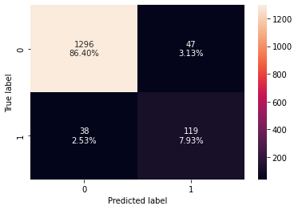

```python
# create confusion matrix
confusion_matrix_sklearn_threshold(
    lg, X_test, y_test, threshold=optimal_threshold_curve
)
```

```python
log_reg_model_test_perf_threshold_curve = model_perf_class_sklearn_threshold(
    lg, X_test, y_test, threshold=optimal_threshold_curve
)
print("Test performance:")
log_reg_model_test_perf_threshold_curve
```

```
Test performance:
```

|  | Accuracy | Recall | Precision | F1 |
| --- | --- | --- | --- | --- |
| 0 | 0.943333 | 0.757962 | 0.716867 | 0.736842 |

# Model performance comparison

```python
# training comparison

models_train_comp_df = pd.concat(
    [
        log_reg_model_train_perf.T,
        log_reg_model_train_perf_threshold_auc_roc.T,
        log_reg_model_train_perf_threshold_curve.T,
    ],
    axis=1,
)
models_train_comp_df.columns = [
    "Logistic Regression sklearn",
    "Logistic Regression-0.079 Threshold",
    "Logistic Regression-0.30 Threshold",
]

print("Training performance comparison:")
models_train_comp_df
```

```
Training performance comparison:
```

|  | Logistic Regression sklearn | Logistic Regression-0.079 Threshold | Logistic Regression-0.30 Threshold |
| --- | --- | --- | --- |
| Accuracy | 0.954000 | 0.874857 | 0.945143 |
| Recall | 0.619195 | 0.916409 | 0.718266 |
| Precision | 0.840336 | 0.418670 | 0.696697 |
| F1 | 0.713012 | 0.574757 | 0.707317 |

```python
# testing comparison

models_test_comp_df = pd.concat(
    [
        log_reg_model_test_perf.T,
        log_reg_model_test_perf_threshold_auc_roc.T,
        log_reg_model_test_perf_threshold_curve.T,
    ],
    axis=1,
)
models_test_comp_df.columns = [
    "Logistic Regression sklearn",
    "Logistic Regression-0.079 Threshold",
    "Logistic Regression-0.30 Threshold",
]

print("Test set performance comparison:")
models_test_comp_df
```

```
Test set performance comparison:
```

|  | Logistic Regression sklearn | Logistic Regression-0.079 Threshold | Logistic Regression-0.30 Threshold |
| --- | --- | --- | --- |
| Accuracy | 0.950000 | 0.866000 | 0.943333 |
| Recall | 0.624204 | 0.904459 | 0.757962 |
| Precision | 0.859649 | 0.432927 | 0.716867 |
| F1 | 0.723247 | 0.585567 | 0.736842 |

# Conclusion

# Building a Decision Tree

### Split Data

```python
X = loan.drop(['Personal_Loan'], axis=1)
y = loan['Personal_Loan']
```

```python
# encoding the categorical variables
X = pd.get_dummies(X, drop_first=True)
X.head()
```

|  | Age | Experience | Income | Family | CCAvg | Education | Mortgage | Securities_Account | CD_Account | Online | CreditCard | County_Butte County | County_Contra Costa County | County_El Dorado County | County_Fresno County | County_Humboldt County | County_Imperial County | County_Kern County | County_Lake County | County_Los Angeles County | County_Marin County | County_Mendocino County | County_Merced County | County_Monterey County | County_Napa County | County_Orange County | County_Placer County | County_Riverside County | County_Sacramento County | … |
| --- | --- | --- | --- | --- | --- | --- | --- | --- | --- | --- | --- | --- | --- | --- | --- | --- | --- | --- | --- | --- | --- | --- | --- | --- | --- | --- | --- | --- | --- | --- |
| 0 | 25 | 1.0 | 49 | 4 | 1.6 | 1 | 0 | 1 | 0 | 0 | 0 | 0 | 0 | 0 | 0 | 0 | 0 | 0 | 0 | 1 | 0 | 0 | 0 | 0 | 0 | 0 | 0 | 0 | 0 | … |
| 1 | 45 | 19.0 | 34 | 3 | 1.5 | 1 | 0 | 1 | 0 | 0 | 0 | 0 | 0 | 0 | 0 | 0 | 0 | 0 | 0 | 1 | 0 | 0 | 0 | 0 | 0 | 0 | 0 | 0 | 0 | … |
| 2 | 39 | 15.0 | 11 | 1 | 1.0 | 1 | 0 | 0 | 0 | 0 | 0 | 0 | 0 | 0 | 0 | 0 | 0 | 0 | 0 | 0 | 0 | 0 | 0 | 0 | 0 | 0 | 0 | 0 | 0 | … |
| 3 | 35 | 9.0 | 100 | 1 | 2.7 | 2 | 0 | 0 | 0 | 0 | 0 | 0 | 0 | 0 | 0 | 0 | 0 | 0 | 0 | 0 | 0 | 0 | 0 | 0 | 0 | 0 | 0 | 0 | 0 | … |
| 4 | 35 | 8.0 | 45 | 4 | 1.0 | 2 | 0 | 0 | 0 | 0 | 1 | 0 | 0 | 0 | 0 | 0 | 0 | 0 | 0 | 1 | 0 | 0 | 0 | 0 | 0 | 0 | 0 | 0 | 0 | … |

```python
X_train, X_test, y_train, y_test = train_test_split(X, y, test_size=0.3, random_state=1)
```

```python
print('Rows in the training data =', X_train.shape[0])
print('Rows in the test data =', X_test.shape[0])
```

```
Rows in the training data = 3500
Rows in the test data = 1500
```

```python
print('Percent of classes in train set:')
print(y_train.value_counts(normalize=True))
print('Percent of classes in test set:')
print(y_test.value_counts(normalize=True))
```

```
Percent of classes in train set:
0    0.905429
1    0.094571
Name: Personal_Loan, dtype: float64
Percent of classes in test set:
0    0.900667
1    0.099333
Name: Personal_Loan, dtype: float64
```

# Model evaluation criterion

### Model can make wrong predictions as:

1. Predicting that a customer will not purchase a personal loan but in reality the customer would purchase a personal loan.
2. Predicting a customer will purchase a personal loan but in reality the customer would not purchase a personal loan.

### Which case is more important?

- If we predict that the correct customer deomographics for customers who would purchase a loan are in fact incorrect by saying they pertain to someone who would not be interested in purchasing a loan, then AllLife Bank would lose the opportunity of providing loans to potential customers.

### How to reduce this loss i.e need to reduce False Negatives?

- recall should be maximized, the greater the recall the greater the chances of minimizing the false negatives.

```python
# function to compute metrics
def model_perf_class_sklearn(model, predictors, target):
    """
    Function to find metrics for checking performance

    model: classifier
    predictors: independent variables
    target: dependent variable
    """
    # predict independent variables
    pred = model.predict(predictors)

    acc = accuracy_score(target, pred)
    recall = recall_score(target, pred)
    precision = precision_score(target, pred)
    f1 = f1_score(target, pred)

    # create df for metrics
    df_perf = pd.DataFrame(
        {'Accuracy': acc, 'Recall': recall, 'Precision': precision, 'F1': f1},
        index=[0]
    )

    return df_perf
```

```python
def confusion_matrix_sklearn(model, predictors, target):
    """
    Confusion matrix with percents

    model: classifier
    predictors: independent variables
    target: dependent variable
    """
    y_pred = model.predict(predictors)
    cm = confusion_matrix(target, y_pred)
    labels = np.asarray(
        [
            ['{0:0.0f}'.format(item) + '\n{0:.2%}'.format(item / cm.flatten().sum())]
            for item in cm.flatten()
        ]
    ).reshape(2, 2)

    plt.figure(figsize=(8, 6))
    sns.heatmap(cm, annot=labels, fmt='')
    plt.ylabel('True label')
    plt.xlabel('Predicted label')
```

# Build Tree

```python
model = DecisionTreeClassifier(criterion='gini', random_state=1)
model.fit(X_train, y_train)
```

```
DecisionTreeClassifier(random_state=1)
```

### Check performance on training set

```python
decision_tree_perf_train = model_perf_class_sklearn(
    model, X_train, y_train
)
decision_tree_perf_train
```

|  | Accuracy | Recall | Precision | F1 |
| --- | --- | --- | --- | --- |
| 0 | 1.0 | 1.0 | 1.0 | 1.0 |

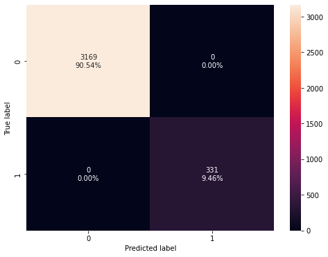

```python
confusion_matrix_sklearn(model, X_train, y_train)
```

### performance on test set

```python
decision_tree_perf_test = model_perf_class_sklearn(
    model, X_test, y_test
)
decision_tree_perf_test
```

|  | Accuracy | Recall | Precision | F1 |
| --- | --- | --- | --- | --- |
| 0 | 0.981333 | 0.872483 | 0.935252 | 0.902778 |

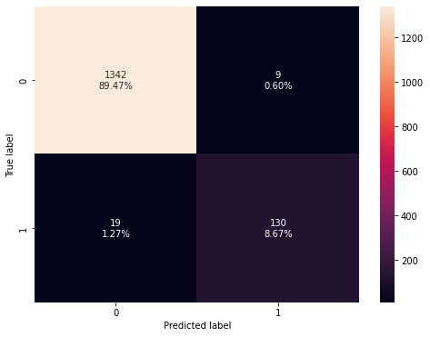

```python
confusion_matrix_sklearn(model, X_test, y_test)
```

# Visualizing the Decision Tree

```python
col_names = list(X.columns)
feat_names = col_names
print(feat_names)
```

```
['Age', 'Experience', 'Income', 'Family', 'CCAvg', 'Education', 'Mortgage', 'Securities_Account', 'CD_Account', 'Online', 'CreditCard', 'County_Butte County', 'County_Contra Costa County', 'County_El Dorado County', 'County_Fresno County', 'County_Humboldt County', 'County_Imperial County', 'County_…
```

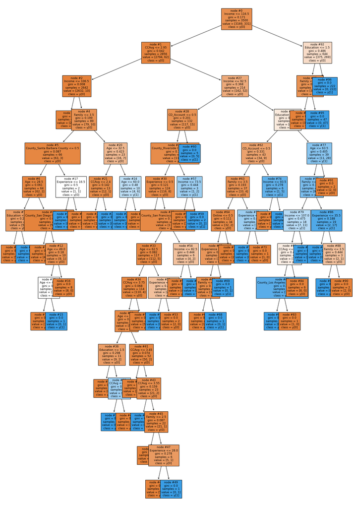

```python
plt.figure(figsize=(20, 30))

out = tree.plot_tree(
    model,
    feature_names=feat_names,
    filled=True,
    fontsize=9,
    node_ids=True,
    class_names=True
)

for o in out:
    arrow = o.arrow_patch
    if arrow is not None:
      arrow.set_edgecolor('black')
      arrow.set_linewidth(1)
plt.show()
```

```python
# Text report of decision tree
print(tree.export_text(model, feature_names=feat_names, show_weights=True))
```

```
|--- Income <= 116.50
|   |--- CCAvg <= 2.95
|   |   |--- Income <= 106.50
|   |   |   |--- weights: [2553.00, 0.00] class: 0
|   |   |--- Income >  106.50
|   |   |   |--- Family <= 3.50
|   |   |   |   |--- County_Santa Barbara County <= 0.50
|   |   |   |   |   |--- Age <= 28.50
|   |   |   |   |   |   |--- Education <= 1.50
|   |   |   |   |   |   |   |--- weights: [5.00, 0.00] class: 0
|   |   |   |   |   |   |--- Education >  1.50
|   |   |   |   |   |   |   |--- weights: [0.00, 1.00] class: 1
|   |   |   |   |   |--- Age >  28.50
|   |   |   |   |   |   |--- County_San Diego County <= 0.50
|   |   |   |   |   |   |   |--- weights: [48.00, 0.00] class: 0
|   |   |   |   |   |   |--- County_San Diego County >  0.50
|   |   |   |   |   |   |   |--- Age <= 49.00
|   |   |   |   |   |   |   |   |--- Age <= 44.50
|   |   |   |   |   |   |   |   |   |--- weights: [1.00, 0.00] class: 0
|   |   |   |   |   |   |   |   |--- Age >  44.50
|   |   |   |   |   |   |   |   |   |--- weights: [0.00, 1.00] class: 1
|   |   |   |   |   |   |   |--- Age >  49.00
|   |   |   |   |   |   |   |   |--- weights: [8.00, 0.00] class: 0
|   |   |   |   |--- County_Santa Barbara County >  0.50
|   |   |   |   |   |--- Experience <= 16.50
|   |   |   |   |   |   |--- weights: [0.00, 1.00] class: 1
|   |   |   |   |   |--- Experience >  16.50
|   |   |   |   |   |   |--- weights: [1.00, 0.00] class: 0
|   |   |   |--- Family >  3.50
|   |   |   |   |--- Age <= 32.50
|   |   |   |   |   |--- CCAvg <= 2.40
|   |   |   |   |   |   |--- weights: [12.00, 0.00] class: 0
|   |   |   |   |   |--- CCAvg >  2.40
|   |   |   |   |   |   |--- weights: [0.00, 1.00] class: 1
|   |   |   |   |--- Age >  32.50
|   |   |   |   |   |--- Age <= 60.00
|   |   |   |   |   |   |--- weights: [0.00, 6.00] class: 1
|   |   |   |   |   |--- Age >  60.00
|   |   |   |   |   |   |--- weights: [4.00, 0.00] class: 0
|   |--- CCAvg >  2.95
```

[output cut: 78 more lines]

```
|   |   |   |   |   |   |--- Experience >  35.50
|   |   |   |   |   |   |   |--- Family <= 3.50
|   |   |   |   |   |   |   |   |--- weights: [0.00, 1.00] class: 1
|   |   |   |   |   |   |   |--- Family >  3.50
|   |   |   |   |   |   |   |   |--- weights: [2.00, 0.00] class: 0
|   |   |   |   |--- Age >  63.50
|   |   |   |   |   |--- weights: [2.00, 0.00] class: 0
|--- Income >  116.50
|   |--- Education <= 1.50
|   |   |--- Family <= 2.50
|   |   |   |--- weights: [375.00, 0.00] class: 0
|   |   |--- Family >  2.50
|   |   |   |--- weights: [0.00, 47.00] class: 1
|   |--- Education >  1.50
|   |   |--- weights: [0.00, 222.00] class: 1
```

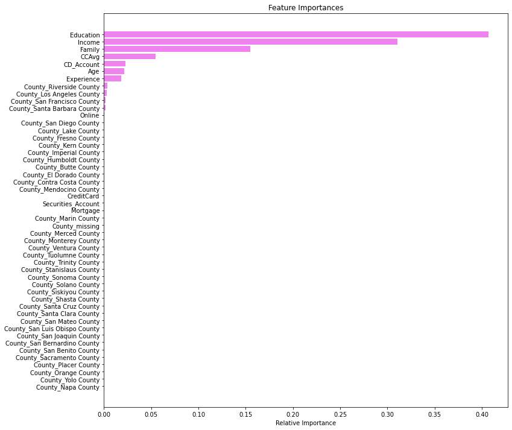

```python
importances = model.feature_importances_
indices = np.argsort(importances)

plt.figure(figsize=(12, 12))
plt.title("Feature Importances")
plt.barh(range(len(indices)), importances[indices], color="violet", align="center")
plt.yticks(range(len(indices)), [feat_names[i] for i in indices])
plt.xlabel("Relative Importance")
plt.show()
```

- Education, Income, and Family are the top 3 important features from the dataset

# Using GridSearch for Hyperparameter tuning of our tree model

- Let's use GridSearch to improve our model further by tuning it

```python
# Choose the type of classifier.
estimator = DecisionTreeClassifier(random_state=1)

# Grid of parameters to choose from

parameters = {
      'max_depth': [2, 20, 5, None],
      'criterion': ['entropy', 'gini'],
      'splitter': ['best', 'random'],
      'min_impurity_decrease': [0.000001, 0.00001, 0.0001]
}

# Type of scoring used to compare parameter combinations
acc_scorer = make_scorer(recall_score)

# Run the grid search
grid_obj = GridSearchCV(estimator, parameters, scoring=acc_scorer, cv=5)
grid_obj = grid_obj.fit(X_train, y_train)

# Set the clf to the best combination of parameters
estimator = grid_obj.best_estimator_

# Fit the best algorithm to the data.
estimator.fit(X_train, y_train)
```

```
DecisionTreeClassifier(criterion='entropy', max_depth=20,
                       min_impurity_decrease=1e-06, random_state=1)
```

# Checking performance on training set

```python
decision_tree_tune_perf_train = model_perf_class_sklearn(
    estimator, X_train, y_train
)
decision_tree_tune_perf_train
```

|  | Accuracy | Recall | Precision | F1 |
| --- | --- | --- | --- | --- |
| 0 | 1.0 | 1.0 | 1.0 | 1.0 |

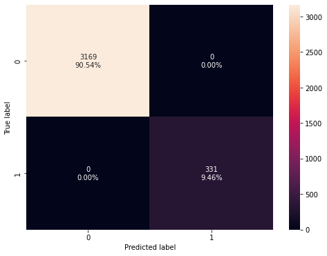

```python
confusion_matrix_sklearn(estimator, X_train, y_train)
```

# Checking model performance on test set

```python
decision_tree_tune_perf_test = model_perf_class_sklearn(
    estimator, X_test, y_test
)
decision_tree_tune_perf_test
```

|  | Accuracy | Recall | Precision | F1 |
| --- | --- | --- | --- | --- |
| 0 | 0.977333 | 0.85906 | 0.907801 | 0.882759 |

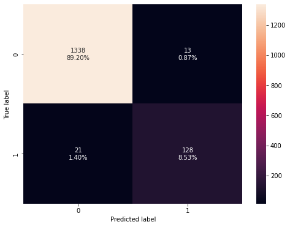

```python
confusion_matrix_sklearn(estimator, X_test, y_test)
```

- After hyperparameter tuning the training performance has remained the same but the test performance metrics have shown a slight decrease across the board for all metrics and the model has become simpler.

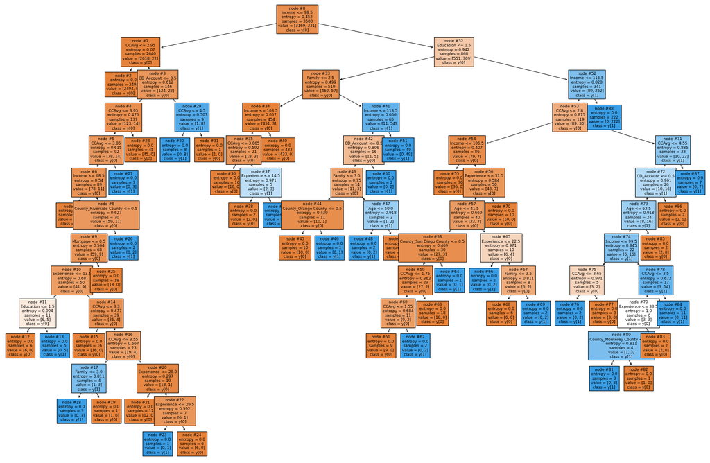

```python
plt.figure(figsize=(30, 20))

tree.plot_tree(
    estimator,
    feature_names=feat_names,
    filled=True,
    fontsize=9,
    node_ids=True,
    class_names=True
)
plt.show()

for o in out:
    arrow = o.arrow_patch
    if arrow is not None:
      arrow.set_edgecolor('black')
      arrow.set_linewidth(1)
plt.show()
```

# Cost Complexity Pruning

```python
clf = DecisionTreeClassifier(random_state=1)
path = clf.cost_complexity_pruning_path(X_train, y_train)
ccp_alphas, impurities = path.ccp_alphas, path.impurities
```

```python
pd.DataFrame(path)
```

|  | ccp_alphas | impurities |
| --- | --- | --- |
| 0 | 0.000000 | 0.000000 |
| 1 | 0.000187 | 0.000562 |
| 2 | 0.000269 | 0.001636 |
| 3 | 0.000273 | 0.002182 |
| 4 | 0.000274 | 0.004371 |
| 5 | 0.000359 | 0.005447 |
| 6 | 0.000381 | 0.005828 |
| 7 | 0.000381 | 0.006209 |
| 8 | 0.000381 | 0.006590 |
| 9 | 0.000476 | 0.007066 |
| 10 | 0.000490 | 0.007556 |
| 11 | 0.000514 | 0.009097 |
| 12 | 0.000527 | 0.009625 |
| 13 | 0.000582 | 0.010207 |
| 14 | 0.000607 | 0.010814 |
| 15 | 0.000642 | 0.011455 |
| 16 | 0.000750 | 0.014456 |
| 17 | 0.000882 | 0.017985 |
| 18 | 0.001552 | 0.019536 |
| 19 | 0.002333 | 0.021869 |
| 20 | 0.003024 | 0.024893 |
| 21 | 0.003294 | 0.028187 |
| 22 | 0.006473 | 0.034659 |
| 23 | 0.023866 | 0.058525 |
| 24 | 0.056365 | 0.171255 |

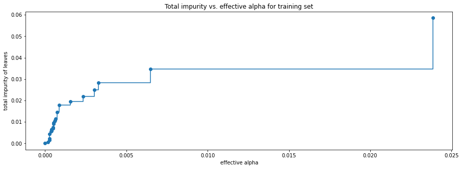

```python
fig, ax = plt.subplots(figsize=(15, 5))
ax.plot(ccp_alphas[:-1], impurities[:-1], marker='o', drawstyle='steps-post')
ax.set_xlabel('effective alpha')
ax.set_ylabel('total impurity of leaves')
ax.set_title('Total impurity vs. effective alpha for training set')
plt.show()
```

Now we can train a tree using effective alphas. The last value in ccp_alphas is the value that prunes the whole tree, leaving the tree, clfs[-1], with one node.

```python
clfs = []
for ccp_alpha in ccp_alphas:
    clf = DecisionTreeClassifier(random_state=1, ccp_alpha=ccp_alpha)
    clf.fit(X_train, y_train)
    clfs.append(clf)
print(
    'Number of nodes in the last tree is: {} with ccp_alpha: {}'.format(
        clfs[-1].tree_.node_count, ccp_alphas[-1]
    )
)
```

```
Number of nodes in the last tree is: 1 with ccp_alpha: 0.056364969335601575
```

Now we can remove the last element in clfs and ccp_alphas, because it has only one node. Number of nodes and tree depth should decreases as alpha increases.

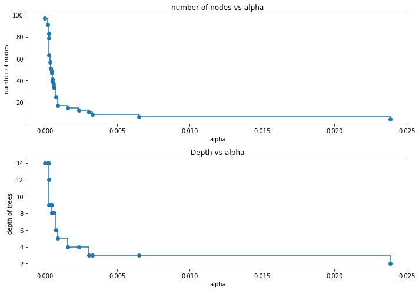

```python
clfs = clfs[:-1]
ccp_alphas = ccp_alphas[:-1]

node_counts = [clf.tree_.node_count for clf in clfs]
depth = [clf.tree_.max_depth for clf in clfs]
fig, ax = plt.subplots(2, 1, figsize=(10,7))
ax[0].plot(ccp_alphas, node_counts, marker='o', drawstyle='steps-post')
ax[0].set_xlabel('alpha')
ax[0].set_ylabel('number of nodes')
ax[0].set_title('number of nodes vs alpha')
ax[1].plot(ccp_alphas, depth, marker='o', drawstyle='steps-post')
ax[1].set_xlabel('alpha')
ax[1].set_ylabel('depth of trees')
ax[1].set_title('Depth vs alpha')
fig.tight_layout()
```

Recall vs alpha for train and test

```python
recall_train = []
for clf in clfs:
    pred_train = clf.predict(X_train)
    values_train = recall_score(y_train, pred_train)
    recall_train.append(values_train)
```

```python
recall_test = []
for clf in clfs:
    pred_test = clf.predict(X_test)
    values_test = recall_score(y_test, pred_test)
    recall_test.append(values_test)
```

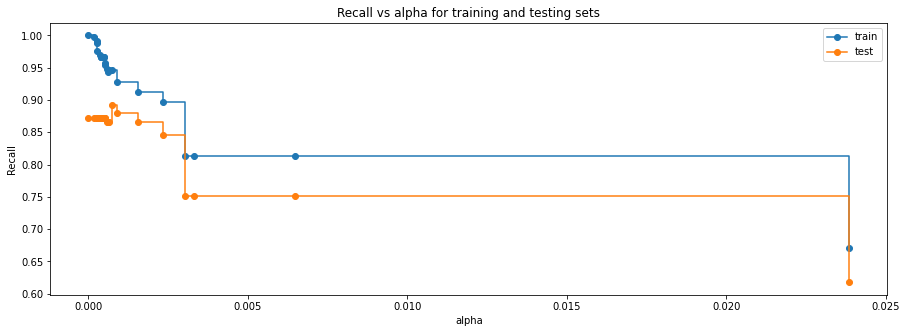

```python
fig, ax = plt.subplots(figsize=(15,5))
ax.set_xlabel('alpha')
ax.set_ylabel('Recall')
ax.set_title('Recall vs alpha for training and testing sets')
ax.plot(ccp_alphas, recall_train, marker='o', label='train', drawstyle='steps-post')
ax.plot(ccp_alphas, recall_test, marker='o', label='test', drawstyle='steps-post')
ax.legend()
plt.show()
```

```python
# create model with highest train and test recall
index_best_model = np.argmax(recall_test)
best_model = clfs[index_best_model]
print(best_model)
```

```
DecisionTreeClassifier(ccp_alpha=0.0007501170508689307, random_state=1)
```

# Checking model performance on training set

```python
decision_tree_postprune_perf_train = model_perf_class_sklearn(
      best_model, X_train, y_train
)
decision_tree_postprune_perf_train
```

|  | Accuracy | Recall | Precision | F1 |
| --- | --- | --- | --- | --- |
| 0 | 0.991429 | 0.945619 | 0.963077 | 0.954268 |

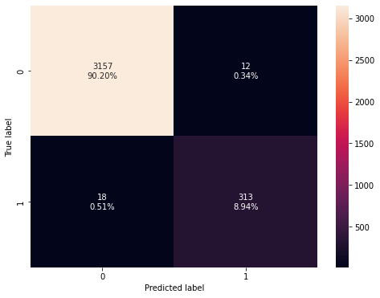

```python
confusion_matrix_sklearn(best_model, X_train, y_train)
```

# Checking model performance on test set

```python
decision_tree_postprune_perf_test = model_perf_class_sklearn(
    best_model, X_test, y_test
)
decision_tree_postprune_perf_test
```

|  | Accuracy | Recall | Precision | F1 |
| --- | --- | --- | --- | --- |
| 0 | 0.982667 | 0.892617 | 0.93007 | 0.910959 |

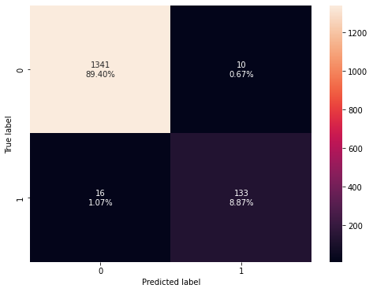

```python
confusion_matrix_sklearn(best_model, X_test, y_test)
```

- With post-pruning we are getting good performance on both training and test set.
- The metrics are all in the 90s for the training set with an Accuracy of 0.99, a Recall of 0.94, a Precision of 0.96, and an f1 score of 0.95.
- The test set has the best model metrics yet for the test data. It has a Recall of 0.89, and all other metrics in the 90s

# Visualizing the Decision Tree

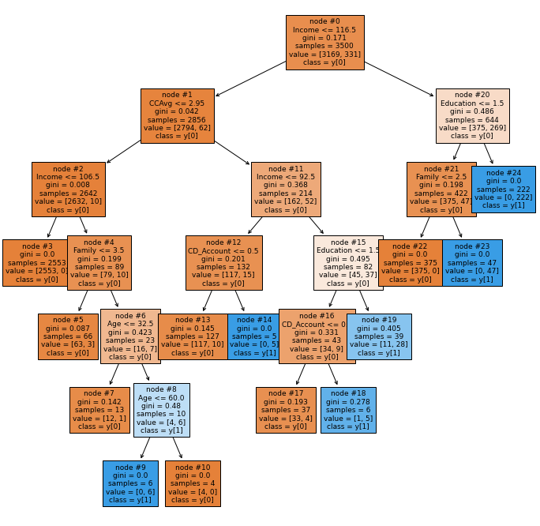

```python
plt.figure(figsize=(12, 12))

out = tree.plot_tree(
    best_model,
    feature_names=feat_names,
    filled=True,
    fontsize=9,
    node_ids=True,
    class_names=True
)
for o in out:
    arrow = o.arrow_patch
    if arrow is not None:
        arrow.set_edgecolor('black')
        arrow.set_linewidth(1)
plt.show()
plt.show()
```

```python
# Text report showing the rules of a decision tree
print(tree.export_text(best_model, feature_names=feat_names, show_weights=True))
```

```
|--- Income <= 116.50
|   |--- CCAvg <= 2.95
|   |   |--- Income <= 106.50
|   |   |   |--- weights: [2553.00, 0.00] class: 0
|   |   |--- Income >  106.50
|   |   |   |--- Family <= 3.50
|   |   |   |   |--- weights: [63.00, 3.00] class: 0
|   |   |   |--- Family >  3.50
|   |   |   |   |--- Age <= 32.50
|   |   |   |   |   |--- weights: [12.00, 1.00] class: 0
|   |   |   |   |--- Age >  32.50
|   |   |   |   |   |--- Age <= 60.00
|   |   |   |   |   |   |--- weights: [0.00, 6.00] class: 1
|   |   |   |   |   |--- Age >  60.00
|   |   |   |   |   |   |--- weights: [4.00, 0.00] class: 0
|   |--- CCAvg >  2.95
|   |   |--- Income <= 92.50
|   |   |   |--- CD_Account <= 0.50
|   |   |   |   |--- weights: [117.00, 10.00] class: 0
|   |   |   |--- CD_Account >  0.50
|   |   |   |   |--- weights: [0.00, 5.00] class: 1
|   |   |--- Income >  92.50
|   |   |   |--- Education <= 1.50
|   |   |   |   |--- CD_Account <= 0.50
|   |   |   |   |   |--- weights: [33.00, 4.00] class: 0
|   |   |   |   |--- CD_Account >  0.50
|   |   |   |   |   |--- weights: [1.00, 5.00] class: 1
|   |   |   |--- Education >  1.50
|   |   |   |   |--- weights: [11.00, 28.00] class: 1
|--- Income >  116.50
|   |--- Education <= 1.50
|   |   |--- Family <= 2.50
|   |   |   |--- weights: [375.00, 0.00] class: 0
|   |   |--- Family >  2.50
|   |   |   |--- weights: [0.00, 47.00] class: 1
|   |--- Education >  1.50
|   |   |--- weights: [0.00, 222.00] class: 1
```

```python
# Important Features

print(
    pd.DataFrame(
        best_model.feature_importances_, columns=['Imp'], index=X_train.columns
    ).sort_values(by='Imp', ascending='False')
)
```

```
                                    Imp
County_Napa County             0.000000
County_Placer County           0.000000
County_Riverside County        0.000000
County_Sacramento County       0.000000
County_San Benito County       0.000000
County_San Bernardino County   0.000000
County_San Diego County        0.000000
County_San Francisco County    0.000000
County_San Joaquin County      0.000000
County_San Luis Obispo County  0.000000
County_San Mateo County        0.000000
County_Santa Barbara County    0.000000
County_Santa Clara County      0.000000
County_Santa Cruz County       0.000000
County_Shasta County           0.000000
County_Siskiyou County         0.000000
County_Solano County           0.000000
County_Sonoma County           0.000000
County_Stanislaus County       0.000000
County_Trinity County          0.000000
County_Tuolumne County         0.000000
County_Ventura County          0.000000
County_Orange County           0.000000
County_Yolo County             0.000000
County_missing                 0.000000
County_Merced County           0.000000
Experience                     0.000000
Mortgage                       0.000000
Securities_Account             0.000000
Online                         0.000000
CreditCard                     0.000000
County_Monterey County         0.000000
County_Contra Costa County     0.000000
County_El Dorado County        0.000000
County_Butte County            0.000000
County_Humboldt County         0.000000
County_Imperial County         0.000000
County_Kern County             0.000000
County_Lake County             0.000000
County_Los Angeles County      0.000000
County_Marin County            0.000000
County_Mendocino County        0.000000
County_Fresno County           0.000000
Age                            0.014382
CD_Account                     0.024775
CCAvg                          0.041281
Family                         0.156373
Income                         0.325272
Education                      0.437917
```

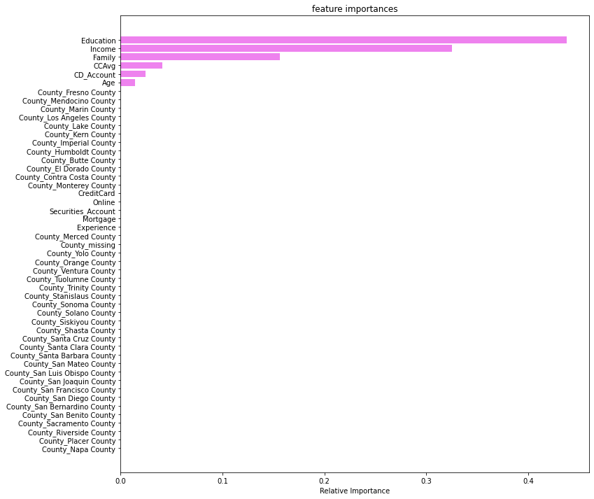

```python
importances = best_model.feature_importances_
indices = np.argsort(importances)

plt.figure(figsize=(12, 12))
plt.title('feature importances')
plt.barh(range(len(indices)), importances[indices], color='violet', align='center')
plt.yticks(range(len(indices)), [feat_names[i] for i in indices])
plt.xlabel('Relative Importance')
plt.show()
```

The most important features are still Education, Income, and Family post pruning

# Comparing all the decision tree models

```python
# training performance comparison
models_train_comp_df = pd.concat(
    [
        decision_tree_perf_train.T,
        decision_tree_tune_perf_train.T,
        decision_tree_postprune_perf_train.T
    ],
    axis=1
)
models_train_comp_df.columns = [
    'Decision Tree sklearn',
    'Deision Tree (pre-pruning)',
    'Decision Tree (post-pruning)'
]
print('Training Performance Comparison:')
models_train_comp_df
```

```
Training Performance Comparison:
```

|  | Decision Tree sklearn | Deision Tree (pre-pruning) | Decision Tree (post-pruning) |
| --- | --- | --- | --- |
| Accuracy | 1.0 | 1.0 | 0.991429 |
| Recall | 1.0 | 1.0 | 0.945619 |
| Precision | 1.0 | 1.0 | 0.963077 |
| F1 | 1.0 | 1.0 | 0.954268 |

```python
# test performance comparison
models_test_comp_df = pd.concat(
     [
         decision_tree_perf_test.T,
         decision_tree_tune_perf_test.T,
         decision_tree_postprune_perf_test.T
     ], axis=1
)
models_test_comp_df.columns = [
    'Decision Tree sklearn',
    'Deision Tree (pre-pruning)',
    'Decision Tree (post-pruning)'
]
print('Testing Performance Comparision:')
models_test_comp_df
```

```
Testing Performance Comparision:
```

|  | Decision Tree sklearn | Deision Tree (pre-pruning) | Decision Tree (post-pruning) |
| --- | --- | --- | --- |
| Accuracy | 0.981333 | 0.977333 | 0.982667 |
| Recall | 0.872483 | 0.859060 | 0.892617 |
| Precision | 0.935252 | 0.907801 | 0.930070 |
| F1 | 0.902778 | 0.882759 | 0.910959 |

- post-pruning on the test set shows the highest recall value.
- The tree with post pruning is not as complex and is easier to interpret.

# Business Insights

- I would tell AllLife Bank's marketing department that Education, Income, and family are the metrics that they really want to focus on when creating their targeted marketing campaign. These are the most important features in determining whether or not a customer will purchase a personal loan.
- For Education, we saw earlier in the EDA that category 3 - Advanced/Professional level of education had the highest number of customers who accepted a personal loan at 205 out of 1501 customers, giving an acceptance rate of 14%. Category 2 - Graduate level education was a very close 2nd with 182 out of 1403 customers purchasing a personal loan, for an acceptance rate of 13%. Then category 1 - undergrad education level had 93 out of 2096 which is an acceptance rate of 4%.
- Based on these results, and Education being the most important feature, I would strongly reccomend focusing on targeted marketing aimed at customers who have an Advanced/Professional Education level and those that have a Graduate level education. Customers at these education levels will have the highest chances of purchasing a personal loan. There is a lot of untapped potential in this market as 58%, over half of your customers, fall within these two education levels.
- Income is 2nd most important feature. With Income though, there is a larger spread of the data across many different individual income levels. One of the biggest things I could see from the EDA was that no cutomers making under 60,000 purchased a loan. This lines up well with Education level as those with higher levels of Education tend to have higher Incomes.
- Looking at the top Income levels from the Bivariate Analysis, customers with 130,000 and 182,000 were the top categories with 11 customers at each income level accepting a personal loan. Then 158,000 and 135,000 were the next 2 income levels with 10 customers each. So you can see just from these top income levels, for personal loan purchases, that the values vary on a wide range of incomes.
- I would highly reccomend taking the Income feature and segmenting it by larger income groups in order to get a more readable picture. Something such as < 60k, 60k > 120k, 120k > 180k, and so on. This would help to see what income ranges have the highest personal loan purchases instead of just focusing on above 60k and then some individualized income levels from the EDA.
- Family was the 3rd major feature impacting a customers likelihood to purchase a personal loan. Looking at the EDA, 3 and 4 person families had the highest number of customers purchasing personal loans.
- The 4 person family category had 134 customers out of 1,222 purchase personal loans, for an acceptance rate of 11%. 3 person families had 133 customers purchase a loan, only 1 less than 4 person families, but for 3 person families the acceptance rate was higher at 13%.
- There was also just a single person difference between 1 and 2 person families, with individuals haveing purchased 107 personal loans for an acceptance rate of 7%. 2 person families had 106 customers purchase a personal loan for an acceptance rate of 8%.

### Target Consumer:

- Taking all of this information into account, I would reccomend that AllLife Bank's marketing department look at all the customers who have a 3 or 4 person Family, who also have a Graduate or an Advanced/Professional level of education, and make over 60,000 per year. The customers who fit all of these criteria are going to be the customers most likely to purchase a personal loan, based on the data.

```python
!jupyter nbconvert --to html /content/Personal_Loan_Campaign_Jonathan_Hutcheson.ipynb
```

[output not shown]

[output cut: 107 more lines]

[output not shown]